# Cyclistic Bike Share Analysis

Achala Jain

2026-06-26

# Introduction

Cyclistic is a bike-share company in Chicago. The objective of this analysis is to understand how casual riders and annual members use Cyclistic bikes differently and identify opportunities to increase annual memberships.

# Business Task

The marketing team wants to convert more casual riders into annual members.

# Data Source

The dataset used in this analysis was obtained as part of the Cyclistic Bike Share Case Study in the Google Data Analytics Professional Certificate on Coursera. The trip data is provided by Divvy, Chicago’s bike-sharing system, and is made available for educational and analytical purposes.

Monthly trip data files from January 2025 to May 2026 were downloaded and combined for analysis. The dataset includes information such as ride start and end times, bike type, station information, ride locations, and rider category (member or casual).

# Data Preparation

## Load Required Libraries

```r
library(tidyverse)
```

```r
library(lubridate)
library(ggplot2)
```

## Import and Combine Files

```r
files <- list.files(
  path = "C:/Users/HP/Desktop/capstone project",
  pattern = "*.csv",
  full.names = TRUE
)

cyclistic <- bind_rows(lapply(files, read_csv))
```

The monthly CSV files were combined into a single dataset.

# Data Cleaning

## Check Dataset Dimensions

```r
dim(cyclistic)
```

```
## [1] 7311224      13
```

## Missing Values

```r
colSums(is.na(cyclistic))
```

```
##            ride_id      rideable_type         started_at           ended_at
##                  0                  0                  0                  0
## start_station_name   start_station_id   end_station_name     end_station_id
##            1528340            1528340            1604711            1604711
##          start_lat          start_lng            end_lat            end_lng
##                  0                  0               7095               7095
##      member_casual
##                  0
```

## Check for duplicate ride IDs

```r
sum(duplicated(cyclistic$ride_id))
```

```
## [1] 35
```

## Removing Duplicate Values

```r
cyclistic <- cyclistic %>%
  distinct(ride_id, .keep_all = TRUE)
dim(cyclistic)
```

```
## [1] 7311189      13
```

## 35 duplicate records were removed

## Create year column for validation

```r
cyclistic$year <- year(cyclistic$started_at)
```

## Check years present

```r
cyclistic %>%
  count(year)
```

```
## # A tibble: 3 × 2
##    year       n
##   <dbl>   <int>
## 1  2024      53
## 2  2025 5552964
## 3  2026 1758172
```

## Remove 2024 Records

```r
cyclistic <- cyclistic %>%
  filter(year %in% c(2025, 2026))
summary(cyclistic$year)
```

```
##    Min. 1st Qu.  Median    Mean 3rd Qu.    Max.
##    2025    2025    2025    2025    2025    2026
```

## Convert Date columns

```r
cyclistic$started_at <- as.POSIXct(cyclistic$started_at)
cyclistic$ended_at <- as.POSIXct(cyclistic$ended_at)
```

## Create Ride_length column

```r
cyclistic$ride_length_min <- as.numeric(
  difftime(
    cyclistic$ended_at,
    cyclistic$started_at,
    units = "mins"
  )
)
```

## Checking for invalid values

```r
summary(cyclistic$ride_length_min)
```

```
##     Min.  1st Qu.   Median     Mean  3rd Qu.     Max.
##  -54.795    5.261    9.194   15.642   16.193 1574.900
```

```r
sum(cyclistic$ride_length_min < 0,na.rm=TRUE)
```

```
## [1] 29
```

```r
sum(cyclistic$ride_length_min == 0,na.rm=TRUE)
```

```
## [1] 0
```

## Remove Invalid Records

```r
cyclistic <- cyclistic %>%
  filter(ride_length_min > 0)
dim(cyclistic)
```

```
## [1] 7311107      15
```

### 29 records with negative ride durations were removed.

## Create Date Variables

```r
cyclistic$month <- month(cyclistic$started_at, label = TRUE)
cyclistic$hour <- hour(cyclistic$started_at)
cyclistic$day_of_week <- weekdays(cyclistic$started_at)
cyclistic$day_of_week <- factor(cyclistic$day_of_week,
                                levels = c("Monday",
                                           "Tuesday",
                                           "Wednesday",
                                           "Thursday",
                                           "Friday",
                                           "Saturday",
                                           "Sunday"))
```

# Exploratory Data Analysis

## 1. Number of Rides by Rider Type

```
## # A tibble: 2 × 2
##   member_casual       n
##   <chr>           <int>
## 1 casual        2529836
## 2 member        4781271
```

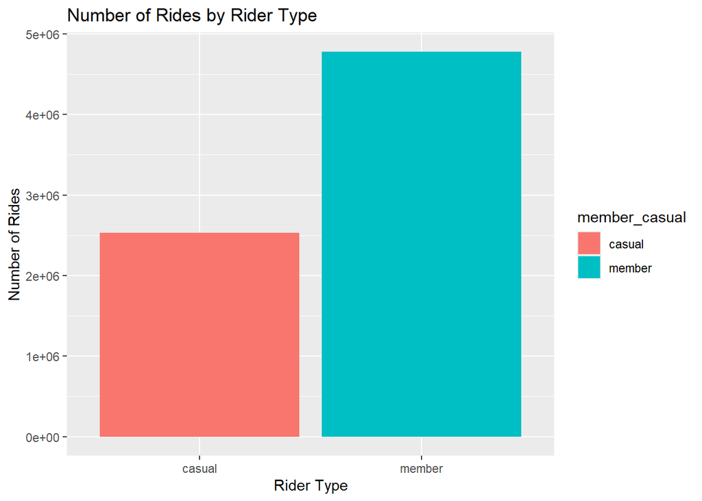

**Insight:** **Members generated significantly more rides than casual riders, indicating that they use the bike-sharing service more frequently and consistently. While casual riders contributed fewer rides overall, they still represent a large user segment and a strong opportunity for membership conversion.**

## 2. Average Ride Length

```
## # A tibble: 2 × 2
##   member_casual avg_ride
##   <chr>            <dbl>
## 1 casual            22.1
## 2 member            12.2
```

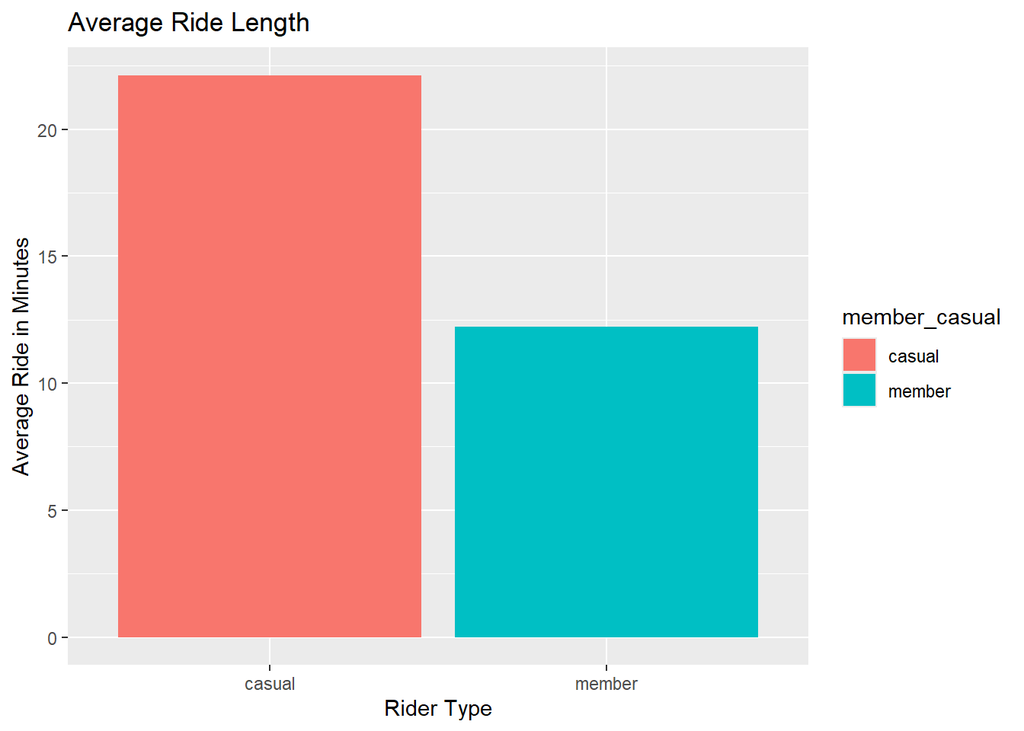

**Insight:** **Casual riders had longer average ride durations than members.**

## 3.Weekly Usage

```
## # A tibble: 14 × 3
##    day_of_week member_casual      n
##    <fct>       <chr>          <int>
##  1 Monday      casual        296996
##  2 Monday      member        675348
##  3 Tuesday     casual        284924
##  4 Tuesday     member        757714
##  5 Wednesday   casual        282385
##  6 Wednesday   member        749621
##  7 Thursday    casual        323352
##  8 Thursday    member        774314
##  9 Friday      casual        400294
## 10 Friday      member        710044
## 11 Saturday    casual        522098
## 12 Saturday    member        601525
## 13 Sunday      casual        419787
## 14 Sunday      member        512705
```

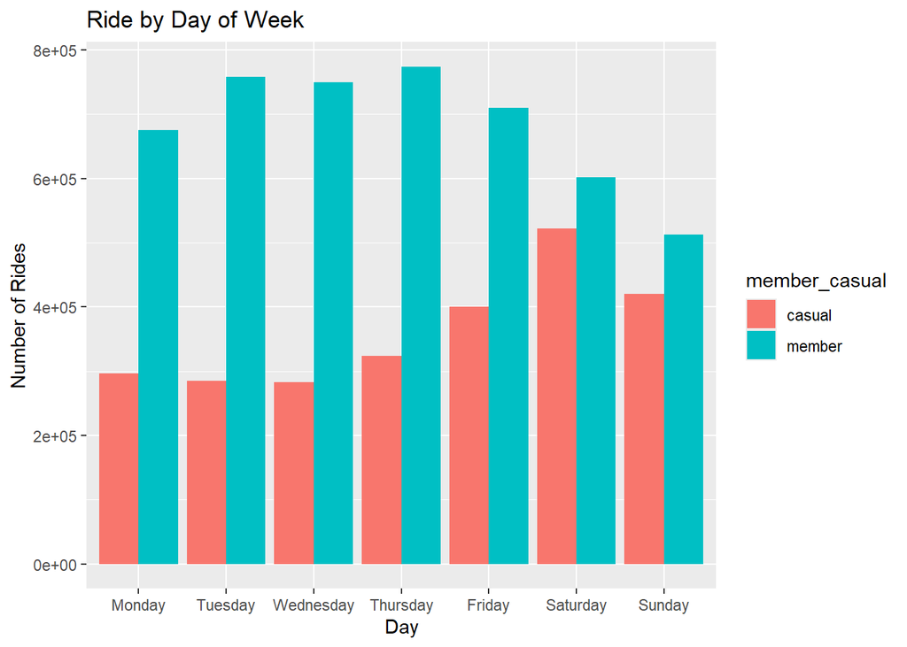

**Insight:** **Members took more rides than casual riders on every day of the week. Casual rider activity increased substantially on weekends, especially Saturday, while members maintained relatively high usage throughout the week. This suggests that members use bikes more regularly, whereas casual riders are more likely to ride for leisure purposes.**

## 4. Monthly Ride Trends (2025)

```
## # A tibble: 24 × 3
##    month member_casual      n
##    <ord> <chr>          <int>
##  1 Jan   casual         24124
##  2 Jan   member        114527
##  3 Feb   casual         27757
##  4 Feb   member        124144
##  5 Mar   casual         85862
##  6 Mar   member        212268
##  7 Apr   casual        109239
##  8 Apr   member        262137
##  9 May   casual        182770
## 10 May   member        319845
## # ℹ 14 more rows
```

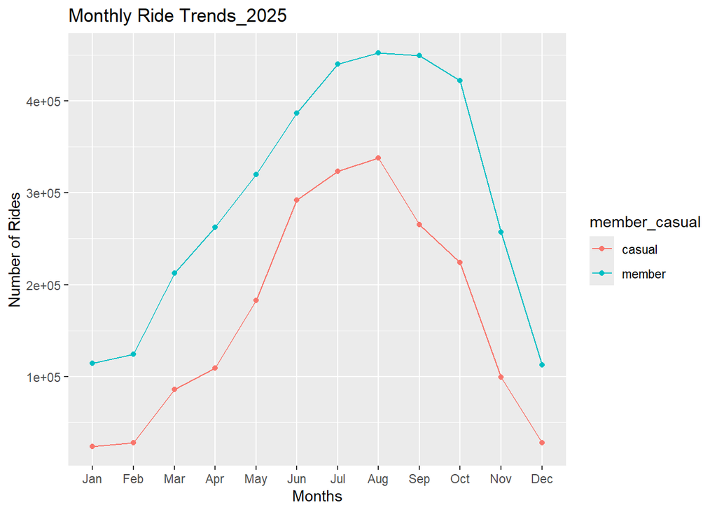

**Insight:** **Members took more rides than casual riders throughout 2025. Both groups exhibited clear seasonal patterns, with ride counts increasing from spring and peaking during July and August before declining in winter. Casual riders showed greater seasonal variation, suggesting that they primarily use bikes for leisure and recreational purposes. The summer months present an ideal opportunity for targeted membership marketing campaigns.**

## 5.Hourly Ride Usage

```
## # A tibble: 48 × 4
##     hour member_casual      n hour_label
##    <int> <chr>          <int> <fct>
##  1    17 member        517715 5 PM
##  2    16 member        456467 4 PM
##  3    18 member        397052 6 PM
##  4     8 member        350336 8 AM
##  5    15 member        322218 3 PM
##  6    19 member        272695 7 PM
##  7     7 member        269375 7 AM
##  8    12 member        255465 12 PM
##  9    14 member        254989 2 PM
## 10    13 member        250520 1 PM
## # ℹ 38 more rows
```

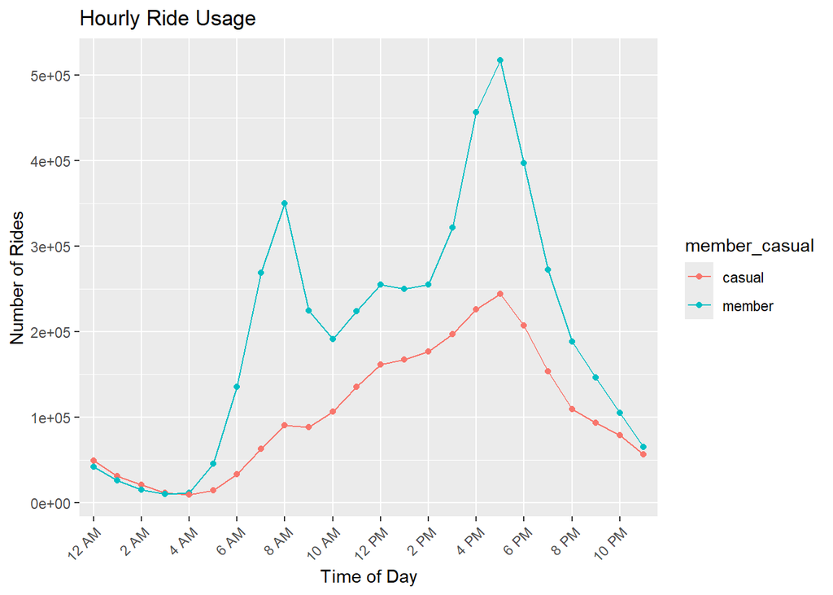

## 6. Bike Type Preference

```
## # A tibble: 4 × 3
##   member_casual rideable_type       n
##   <chr>         <chr>           <int>
## 1 casual        classic_bike   814468
## 2 casual        electric_bike 1715368
## 3 member        classic_bike  1669786
## 4 member        electric_bike 3111485
```

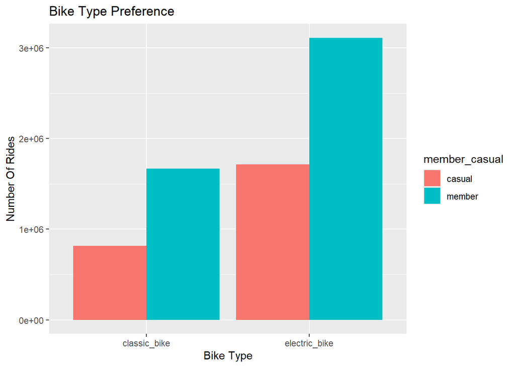

**Insight:** **Electric bikes were the most preferred bike type among both casual riders and members. Members recorded more rides than casual riders for both bike categories, indicating higher overall usage. The strong preference for electric bikes suggests that convenience and ease of travel are important factors for both rider groups.**

## 7. Top 10 Stations Used by Casual Riders

```
## # A tibble: 10 × 2
##    start_station_name                     n
##    <chr>                              <int>
##  1 DuSable Lake Shore Dr & Monroe St  39602
##  2 Navy Pier                          38895
##  3 Michigan Ave & Oak St              26959
##  4 Streeter Dr & Grand Ave            23697
##  5 DuSable Lake Shore Dr & North Blvd 23307
##  6 Millennium Park                    23246
##  7 Shedd Aquarium                     21260
##  8 Dusable Harbor                     19240
##  9 Theater on the Lake                18935
## 10 Michigan Ave & 8th St              13435
```

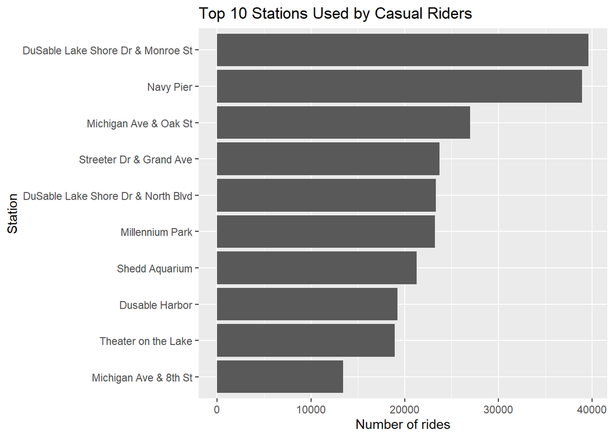

**Insight:** **The most popular stations among casual riders are located near tourist attractions, parks, and lakefront areas such as Navy Pier, Millennium Park, and DuSable Lake Shore Drive. This indicates that casual riders primarily use bikes for leisure and recreational activities rather than daily commuting. These high-traffic stations provide excellent opportunities for targeted membership marketing campaigns.**

# Key Findings

- Members generated significantly more rides than casual riders, indicating more frequent and regular usage.
- Casual riders had longer average ride durations and were more active on weekends, suggesting recreational usage.
- Both rider groups showed strong seasonal trends, with ride activity peaking during summer months.
- Members displayed clear commuting patterns with ride peaks during morning and evening hours.
- Electric bikes were the most preferred bike type, and popular casual rider stations were mainly located near tourist and recreational areas.

# Recommendations

- Target casual riders at popular recreational and tourist stations with membership promotions.
- Launch seasonal marketing campaigns during spring and summer when casual rider activity is highest.
- Highlight membership benefits such as cost savings, convenience, and access to electric bikes.

# Conclusion:

**The analysis showed that members primarily use Cyclistic bikes for regular transportation and commuting, while casual riders use them more for leisure and recreational purposes. By targeting active casual riders with location-based and seasonal marketing campaigns, Cyclistic can increase annual memberships and support future growth.**